# Apartado 4.7.2 Ejercicio 10

Daniel Ceballos Monsalve

Andrés Felipe Mejía Quintero

Doris Steffania Obando Gonzalez

Librerias a utilizar

```r
library(corrplot)
library(PerformanceAnalytics)
library(vcd)
library(MASS)
library(class)
```

## Ejercicio 10

Esta pregunta debe responderse utilizando el conjunto de datos Weekly, que es parte del paquete ISLR. Estos datos son de naturaleza similar a los datos de Smarket del laboratorio de este capítulo, excepto que contienen 1.089 retornos semanales durante 21 años, desde principios de 1990 hasta finales de 2010.

### Solucion enunciado del punto a

Produzca algunos resúmenes numéricos y gráficos de los datos semanales. ¿Parece haber algún patrón?

```r
#Se carga la libreria ISLR:
library(ISLR)

#Se hace el llamado a los datos a utilizar (Weekly) de la libreria ISLR:
data(Weekly)
attach(Weekly)


#Se visualizan las caracteristicas de los datos del dataframe:
summary(Weekly)
```

```
##       Year           Lag1               Lag2               Lag3
##  Min.   :1990   Min.   :-18.1950   Min.   :-18.1950   Min.   :-18.1950
##  1st Qu.:1995   1st Qu.: -1.1540   1st Qu.: -1.1540   1st Qu.: -1.1580
##  Median :2000   Median :  0.2410   Median :  0.2410   Median :  0.2410
##  Mean   :2000   Mean   :  0.1506   Mean   :  0.1511   Mean   :  0.1472
##  3rd Qu.:2005   3rd Qu.:  1.4050   3rd Qu.:  1.4090   3rd Qu.:  1.4090
##  Max.   :2010   Max.   : 12.0260   Max.   : 12.0260   Max.   : 12.0260
##       Lag4               Lag5              Volume            Today
##  Min.   :-18.1950   Min.   :-18.1950   Min.   :0.08747   Min.   :-18.1950
##  1st Qu.: -1.1580   1st Qu.: -1.1660   1st Qu.:0.33202   1st Qu.: -1.1540
##  Median :  0.2380   Median :  0.2340   Median :1.00268   Median :  0.2410
##  Mean   :  0.1458   Mean   :  0.1399   Mean   :1.57462   Mean   :  0.1499
##  3rd Qu.:  1.4090   3rd Qu.:  1.4050   3rd Qu.:2.05373   3rd Qu.:  1.4050
##  Max.   : 12.0260   Max.   : 12.0260   Max.   :9.32821   Max.   : 12.0260
##  Direction
##  Down:484
##  Up  :605
##
##
##
##
```

```r
#Se visualizan los primeros 5 datos iniciales y finales del dataframe:
rbind(head(Weekly,5), tail(Weekly,5))
```

```
##      Year   Lag1   Lag2   Lag3   Lag4   Lag5    Volume  Today Direction
## 1    1990  0.816  1.572 -3.936 -0.229 -3.484 0.1549760 -0.270      Down
## 2    1990 -0.270  0.816  1.572 -3.936 -0.229 0.1485740 -2.576      Down
## 3    1990 -2.576 -0.270  0.816  1.572 -3.936 0.1598375  3.514        Up
## 4    1990  3.514 -2.576 -0.270  0.816  1.572 0.1616300  0.712        Up
## 5    1990  0.712  3.514 -2.576 -0.270  0.816 0.1537280  1.178        Up
## 1085 2010 -0.861  0.043 -2.173  3.599  0.015 3.2051600  2.969        Up
## 1086 2010  2.969 -0.861  0.043 -2.173  3.599 4.2425680  1.281        Up
## 1087 2010  1.281  2.969 -0.861  0.043 -2.173 4.8350820  0.283        Up
## 1088 2010  0.283  1.281  2.969 -0.861  0.043 4.4540440  1.034        Up
## 1089 2010  1.034  0.283  1.281  2.969 -0.861 2.7071050  0.069        Up
```

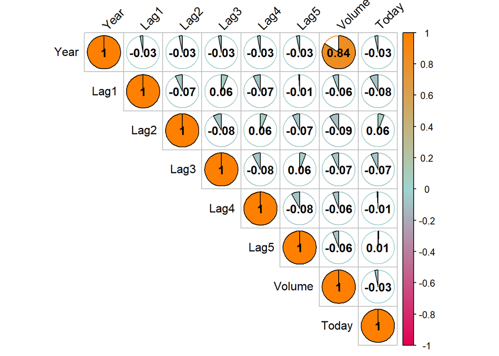

```r
#Se crea la matriz de correlacion:
Correlacion_Weekly <- round(cor(Weekly[,-9]),2)

#Se grafica la parte superior de la matriz de correlacion:
col <- colorRampPalette(c("#E30052","#9FD5D1","#FF8000"))
corrplot(Correlacion_Weekly, method = "pie", type = "upper", shade.col = NA,
         tl.col = "black", tl.srt = 45, addCoef.col = "black",
         addshade = "all", col = col(300))
```

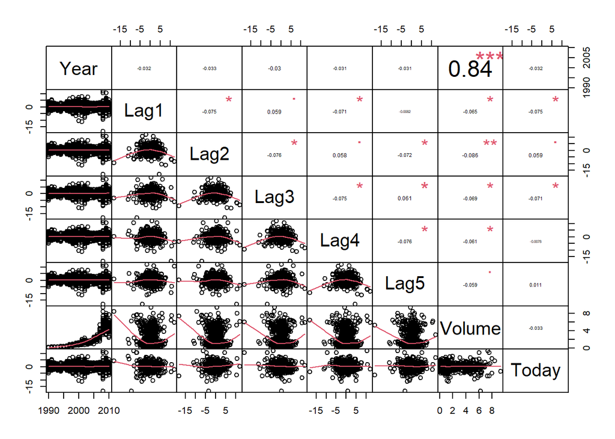

```r
#se hace un diagrama de pares junto con las correlaciones
chart.Correlation(Weekly[,-9], histogram = FALSE, pch = 19)
```

### Solucion enunciado del punto b

Utilice el conjunto de datos completo para realizar una regresión logística con Dirección, como respuesta y las cinco variables de retraso, más Volumen como predictor. Utilice la función de resumen para imprimir los resultados. ¿Alguno de los predictores parece ser estadísticamente significativo? ¿De ser asi, cuales?

```r
Regresion_Logistica = glm(Direction ~ Lag1 + Lag2 + Lag3 + Lag4 + Lag5 + Volume, data = Weekly, family = binomial)
summary(Regresion_Logistica)
```

```
##
## Call:
## glm(formula = Direction ~ Lag1 + Lag2 + Lag3 + Lag4 + Lag5 +
##     Volume, family = binomial, data = Weekly)
##
## Deviance Residuals:
##     Min       1Q   Median       3Q      Max
## -1.6949  -1.2565   0.9913   1.0849   1.4579
##
## Coefficients:
##             Estimate Std. Error z value Pr(>|z|)
## (Intercept)  0.26686    0.08593   3.106   0.0019 **
## Lag1        -0.04127    0.02641  -1.563   0.1181
## Lag2         0.05844    0.02686   2.175   0.0296 *
## Lag3        -0.01606    0.02666  -0.602   0.5469
## Lag4        -0.02779    0.02646  -1.050   0.2937
## Lag5        -0.01447    0.02638  -0.549   0.5833
## Volume      -0.02274    0.03690  -0.616   0.5377
## ---
## Signif. codes:  0 '***' 0.001 '**' 0.01 '*' 0.05 '.' 0.1 ' ' 1
##
## (Dispersion parameter for binomial family taken to be 1)
##
##     Null deviance: 1496.2  on 1088  degrees of freedom
## Residual deviance: 1486.4  on 1082  degrees of freedom
## AIC: 1500.4
##
## Number of Fisher Scoring iterations: 4
```

### Solucion enunciado del punto c

Calcule la matriz de confusión y la fracción total de predicciones. Explica lo que te dice la matriz de confusión sobre los tipos de errores cometidos por la regresión logística.

```r
#Calculo de la matriz de confusión
Probabilidad_Regresion_Logistica <- predict(Regresion_Logistica, type = "response")
Test_R_Logistica <- rep("Down", length(Probabilidad_Regresion_Logistica))
Test_R_Logistica[Probabilidad_Regresion_Logistica > 0.5] = "Up"
Matriz_Confusion <- table(Test_R_Logistica, Direction)
Matriz_Confusion
```

```
##                 Direction
## Test_R_Logistica Down  Up
##             Down   54  48
##             Up    430 557
```

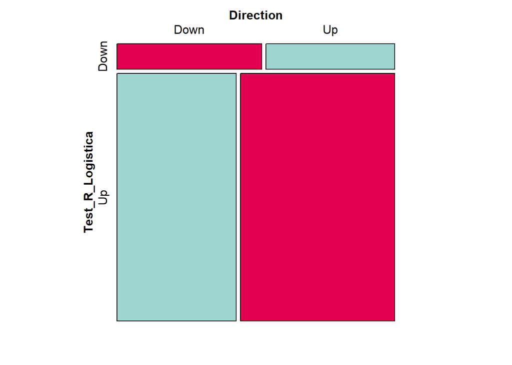

```r
mosaic(Matriz_Confusion, shade = T, colorize = T,
       gp = gpar(fill = matrix(c("#E30052","#9FD5D1", "#9FD5D1", "#E30052"), 2, 2)))
```

### Solucion enunciado del punto d

Ahora ajuste el modelo de regresión logística usando un período de datos de entrenamiento de 1990 a 2008, con Lag2 como único predictor. Calcule la matriz de confusión y la fracción general de predicciones correctas para los datos retenidos (es decir, los datos de 2009 y 2010).

```r
#Se toman los datos que se encuentran en el intervalo [1998,2008]
Data_Train = (Year < 2009)
Data_Retenido = Weekly[!Data_Train, ]

segunda_Regresion_Logistica = glm(Direction ~ Lag2, data = Weekly, family = binomial, subset = Data_Train)

Probabilidad_2R_Logistica = predict(segunda_Regresion_Logistica, Data_Retenido, type = "response")
Test_2R_Logistica = rep("Down", length(Probabilidad_2R_Logistica))
Test_2R_Logistica[Probabilidad_2R_Logistica > 0.5] = "Up"

Direction_Retenido = Direction[!Data_Train]

#Porcentaje de predicciones correctas
paste("El porcentaje de predicciones correctas es de ", mean(Test_2R_Logistica == Direction_Retenido)*100, "%")
```

```
## [1] "El porcentaje de predicciones correctas es de  62.5 %"
```

```r
#Tabla de la segunda matriz de confusión con las consideraciones del enunciado
table(Test_2R_Logistica, Direction_Retenido)
```

```
##                  Direction_Retenido
## Test_2R_Logistica Down Up
##              Down    9  5
##              Up     34 56
```

### Solucion enunciado del punto e

Repita el punto d usando LDA.

```r
#Modelo utilizando LDA
Modelo_LDA = lda(Direction ~ Lag2, data = Weekly, subset = Data_Train)
Test_LDA = predict(Modelo_LDA, Data_Retenido)

#Porcentaje de predicciones correctas
paste("El porcentaje de predicciones correctas es de ", mean(Test_LDA$class == Direction_Retenido)*100, "%")
```

```
## [1] "El porcentaje de predicciones correctas es de  62.5 %"
```

```r
#Matriz de confusión por usar  LDA
table(Test_LDA$class, Direction_Retenido)
```

```
##       Direction_Retenido
##        Down Up
##   Down    9  5
##   Up     34 56
```

### Solucion enunciado del punto f

Repita el punto d usando QDA.

```r
#Modelo utilizando QDA
Modelo_QDA = qda(Direction ~ Lag2, data = Weekly, subset = Data_Train)
Test_QDA = predict(Modelo_QDA, Data_Retenido)

#Porcentaje de predicciones correctas
paste("El porcentaje de predicciones correctas es de ", round(mean(Test_QDA$class == Direction_Retenido)*100,1), "%")
```

```
## [1] "El porcentaje de predicciones correctas es de  58.7 %"
```

```r
#Matriz de confusión por usar  QDA
table(Test_QDA$class, Direction_Retenido)
```

```
##       Direction_Retenido
##        Down Up
##   Down    0  0
##   Up     43 61
```

### Solucion enunciado del punto g

Repita el punto d usando KNN con K = 1.

```r
#Implementación para usar KNN
Train_X = as.matrix(Lag2[Data_Train])
Test_X = as.matrix(Lag2[!Data_Train])
Train_Direction = Direction[Data_Train]
set.seed(1)
Prediccion_KNN = knn(Train_X, Test_X, Train_Direction, k = 1)

#Porcentaje de predicciones correctas
paste("El porcentaje de predicciones correctas es de ", round(mean(Prediccion_KNN == Direction_Retenido)*100,1), "%")
```

```
## [1] "El porcentaje de predicciones correctas es de  50 %"
```

```r
#Matriz de confusión por usar  knn
table(Prediccion_KNN, Direction_Retenido)
```

```
##               Direction_Retenido
## Prediccion_KNN Down Up
##           Down   21 30
##           Up     22 31
```

### Solucion enunciado del punto i

Experimente con diferentes combinaciones de predictores, incluidas las posibles transformaciones e interacciones, para cada uno de los métodos. Informe las variables, el método y la matriz de confusión asociada que parece proporcionar los mejores resultados sobre los datos retenidos. Tenga en cuenta que también debe experimentar con los valores de K en el clasificador KNN.

```r
# Regresión logistica con Lag1 y Lag2:
Regresion_Logistica_3 = glm(Direction ~ Lag1 + Lag2, data = Weekly, family = binomial, subset = Data_Train)
Probabilidad_Regresion_3 = predict(Regresion_Logistica_3, Data_Retenido, type = "response")
Regresion_Logistica_Test_3 = rep("Down", length(Probabilidad_Regresion_3))
Regresion_Logistica_Test_3[Probabilidad_Regresion_3 > 0.5] = "Up"
Direction_Retenido_3 = Direction[!Data_Train]

# Porcentaje de predicciones correctas
paste("El porcentaje de predicciones correctas es de ", round(mean(Regresion_Logistica_Test_3 == Direction_Retenido_3)*100,1), "%")
```

```
## [1] "El porcentaje de predicciones correctas es de  57.7 %"
```

```r
# Matriz de confusión por usar  Regresion logistica con Lag1 y Lag2:
table(Regresion_Logistica_Test_3, Direction_Retenido)
```

```
##                           Direction_Retenido
## Regresion_Logistica_Test_3 Down Up
##                       Down    7  8
##                       Up     36 53
```

```r
# Regresión logistica con Lag1, Lag2 y Lag 4:
Regresion_Logistica_4 = glm(Direction ~ Lag1 + Lag2+Lag4, data = Weekly, family = binomial, subset = Data_Train)
Probabilidad_Regresion_4 = predict(Regresion_Logistica_4, Data_Retenido, type = "response")
Regresion_Logistica_Test_4 = rep("Down", length(Probabilidad_Regresion_4))
Regresion_Logistica_Test_4[Probabilidad_Regresion_4 > 0.5] = "Up"
Direction_Retenido_4 = Direction[!Data_Train]

#Porcentaje de predicciones correctas
paste("El porcentaje de predicciones correctas es de ", round(mean(Regresion_Logistica_Test_4 == Direction_Retenido)*100,1), "%")
```

```
## [1] "El porcentaje de predicciones correctas es de  60.6 %"
```

```r
# Matriz de confusión por usar  Regresion logistica con Lag1, Lag2 y Lag4:
table(Regresion_Logistica_Test_4, Direction_Retenido)
```

```
##                           Direction_Retenido
## Regresion_Logistica_Test_4 Down Up
##                       Down    9  7
##                       Up     34 54
```

```r
#LDA con Lag1 y Lag2:
LDA_2 = lda(Direction ~ Lag2 + Lag1, data = Weekly, subset = Data_Train)
Test_LDA_2 = predict(LDA_2, Data_Retenido)
#table(Test_LDA_2$class, Direction_Retenido)

#Porcentaje de predicciones correctas
paste("El porcentaje de predicciones correctas es de ", round(mean(Test_LDA_2$class == Direction_Retenido)*100,1), "%")
```

```
## [1] "El porcentaje de predicciones correctas es de  57.7 %"
```

```r
# Matriz de confusión por LDA con Lag1 y Lag2:
table(Test_LDA_2$class, Direction_Retenido)
```

```
##       Direction_Retenido
##        Down Up
##   Down    7  8
##   Up     36 53
```

```r
#LDA con Lag1, Lag2 y Lag4:
LDA_3 = lda(Direction ~ Lag2 + Lag1 + Lag4, data = Weekly, subset = Data_Train)
Test_LDA_3 = predict(LDA_3, Data_Retenido)

#Porcentaje de predicciones correctas
paste("El porcentaje de predicciones correctas es de ", round(mean(Test_LDA_3$class == Direction_Retenido)*100,1), "%")
```

```
## [1] "El porcentaje de predicciones correctas es de  60.6 %"
```

```r
# Matriz de confusión por LDA con Lag1, Lag2 y Lag4:
table(Test_LDA_3$class, Direction_Retenido)
```

```
##       Direction_Retenido
##        Down Up
##   Down    9  7
##   Up     34 54
```

```r
#LDA con iteracción entre Lag1 y Lag2:
LDA_4 = lda(Direction ~ Lag2:Lag1, data = Weekly, subset = Data_Train)
Test_LDA_4 = predict(LDA_4, Data_Retenido)

#Porcentaje de predicciones correctas
paste("El porcentaje de predicciones correctas es de ", round(mean(Test_LDA_4$class == Direction_Retenido)*100,1), "%")
```

```
## [1] "El porcentaje de predicciones correctas es de  57.7 %"
```

```r
# Matriz de confusión por LDA con iteracción entre Lag1 y Lag2:
table(Test_LDA_4$class, Direction_Retenido)
```

```
##       Direction_Retenido
##        Down Up
##   Down    0  1
##   Up     43 60
```

```r
#LDA con interacción entre Lag1 y Lag2, entre Lag2 y Lag4:
LDA_5 = lda(Direction ~ Lag2:Lag1+Lag2:Lag4, data = Weekly, subset = Data_Train)
Test_LDA_5 = predict(LDA_5, Data_Retenido)

#Porcentaje de predicciones correctas
paste("El porcentaje de predicciones correctas es de ", round(mean(Test_LDA_5$class == Direction_Retenido)*100,1), "%")
```

```
## [1] "El porcentaje de predicciones correctas es de  57.7 %"
```

```r
# Matriz de confusión por LDA con interacción entre Lag1 y Lag2, entre Lag2 y Lag4:
table(Test_LDA_5$class, Direction_Retenido)
```

```
##       Direction_Retenido
##        Down Up
##   Down    1  2
##   Up     42 59
```

```r
#QDA con interacción entre Lag1 y Lag2, entre Lag2 y Lag4:
QDA_2 = qda(Direction ~ Lag2:Lag1+Lag2:Lag4, data = Weekly, subset = Data_Train)
Test_QDA_2 = predict(QDA_2, Data_Retenido)$class

#Porcentaje de predicciones correctas
paste("El porcentaje de predicciones correctas es de ", round(mean(Test_QDA_2 == Direction_Retenido)*100,1), "%")
```

```
## [1] "El porcentaje de predicciones correctas es de  45.2 %"
```

```r
# Matriz de confusión por QDA con interacción entre Lag1 y Lag2, entre Lag2 y Lag4:
table(Test_QDA_2, Direction_Retenido)
```

```
##           Direction_Retenido
## Test_QDA_2 Down Up
##       Down   23 37
##       Up     20 24
```

```r
#QDA con interacción entre Lag1 y Lag2, entre Lag2 y Lag4 y por ultimo entre Lag1 y Lag4:
QDA_3 = qda(Direction ~ Lag2:Lag1+Lag2:Lag4+Lag1:Lag4, data = Weekly, subset = Data_Train)
Test_QDA_3 = predict(QDA_3, Data_Retenido)$class

#Porcentaje de predicciones correctas
paste("El porcentaje de predicciones correctas es de ", round(mean(Test_QDA_3 == Direction_Retenido)*100,1), "%")
```

```
## [1] "El porcentaje de predicciones correctas es de  59.6 %"
```

```r
# Matriz de confusión por QDA con interacción entre Lag1 y Lag2, entre Lag2 y Lag4 y por ultimo entre Lag1 y Lag4:
table(Test_QDA_3, Direction_Retenido)
```

```
##           Direction_Retenido
## Test_QDA_3 Down Up
##       Down    7  6
##       Up     36 55
```

```r
#QDA con Lag2 y Raiz de Lag2:
QDA_4 = qda(Direction ~ Lag2 + sqrt(abs(Lag2)),  data = Weekly, subset = Data_Train)
Test_QDA_4 = predict(QDA_4, Data_Retenido)$class

#Porcentaje de predicciones correctas
paste("El porcentaje de predicciones correctas es de ", round(mean(Test_QDA_4 == Direction_Retenido)*100,1), "%")
```

```
## [1] "El porcentaje de predicciones correctas es de  57.7 %"
```

```r
# Matriz de confusión por QDA con Lag2 y Raiz de Lag2:
table(Test_QDA_4, Direction_Retenido)
```

```
##           Direction_Retenido
## Test_QDA_4 Down Up
##       Down   12 13
##       Up     31 48
```

```r
#QDA con Lag2 y Raiz de Lag2, Lag1 y Raiz de Lag1:
QDA_5 = qda(Direction ~ Lag2 + sqrt(abs(Lag2)) + Lag1 + sqrt(abs(Lag1)),  data = Weekly, subset = Data_Train)
Test_QDA_5 = predict(QDA_5, Data_Retenido)$class

#Porcentaje de predicciones correctas
paste("El porcentaje de predicciones correctas es de ", round(mean(Test_QDA_5 == Direction_Retenido)*100,1), "%")
```

```
## [1] "El porcentaje de predicciones correctas es de  59.6 %"
```

```r
# Matriz de confusión por QDA con Lag2 y Raiz de Lag2, Lag1 y Raiz de Lag1:
table(Test_QDA_5, Direction_Retenido)
```

```
##           Direction_Retenido
## Test_QDA_5 Down Up
##       Down   18 17
##       Up     25 44
```

```r
#KNN con K=10:
KNN_10 = knn(Train_X, Test_X, Train_Direction, k = 10)

#Porcentaje de predicciones correctas
paste("El porcentaje de predicciones correctas es de ", round(mean(KNN_10 == Direction_Retenido)*100,1), "%")
```

```
## [1] "El porcentaje de predicciones correctas es de  57.7 %"
```

```r
# Matriz de confusión con KNN con K=10:
table(KNN_10, Direction_Retenido)
```

```
##       Direction_Retenido
## KNN_10 Down Up
##   Down   17 18
##   Up     26 43
```

```r
#KNN con K=50:
KNN_50 = knn(Train_X, Test_X, Train_Direction, k = 50)

#Porcentaje de predicciones correctas
paste("El porcentaje de predicciones correctas es de ", round(mean(KNN_50 == Direction_Retenido)*100,1), "%")
```

```
## [1] "El porcentaje de predicciones correctas es de  56.7 %"
```

```r
# Matriz de confusión con KNN con K=50:
table(KNN_50, Direction_Retenido)
```

```
##       Direction_Retenido
## KNN_50 Down Up
##   Down   20 22
##   Up     23 39
```

```r
#KNN con K=100:
KNN_100 = knn(Train_X, Test_X, Train_Direction, k = 100)

#Porcentaje de predicciones correctas
paste("El porcentaje de predicciones correctas es de ", round(mean(KNN_100 == Direction_Retenido)*100,1), "%")
```

```
## [1] "El porcentaje de predicciones correctas es de  55.8 %"
```

```r
# Matriz de confusión con KNN con K=100:
table(KNN_100, Direction_Retenido)
```

```
##        Direction_Retenido
## KNN_100 Down Up
##    Down    9 12
##    Up     34 49
```

```r
#KNN con K=200:
KNN_200 = knn(Train_X, Test_X, Train_Direction, k = 200)

#Porcentaje de predicciones correctas
paste("El porcentaje de predicciones correctas es de ", round(mean(KNN_200 == Direction_Retenido)*100,1), "%")
```

```
## [1] "El porcentaje de predicciones correctas es de  59.6 %"
```

```r
# Matriz de confusión pcon KNN con K=200:
table(KNN_200, Direction_Retenido)
```

```
##        Direction_Retenido
## KNN_200 Down Up
##    Down    2  1
##    Up     41 60
```